# Exploration de la population des communes

Mathilde Mousset

26 mars 2019

# Infos générales

Nb de communes par département:

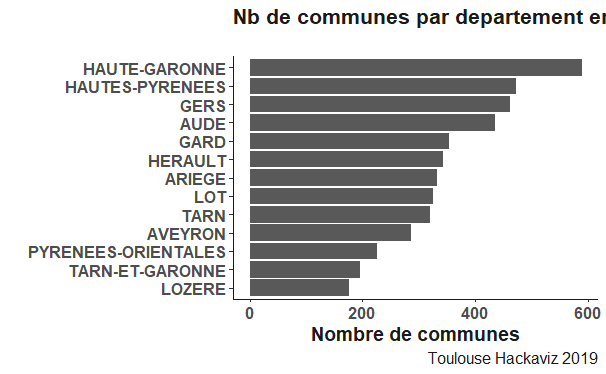

Let’s try to get a map

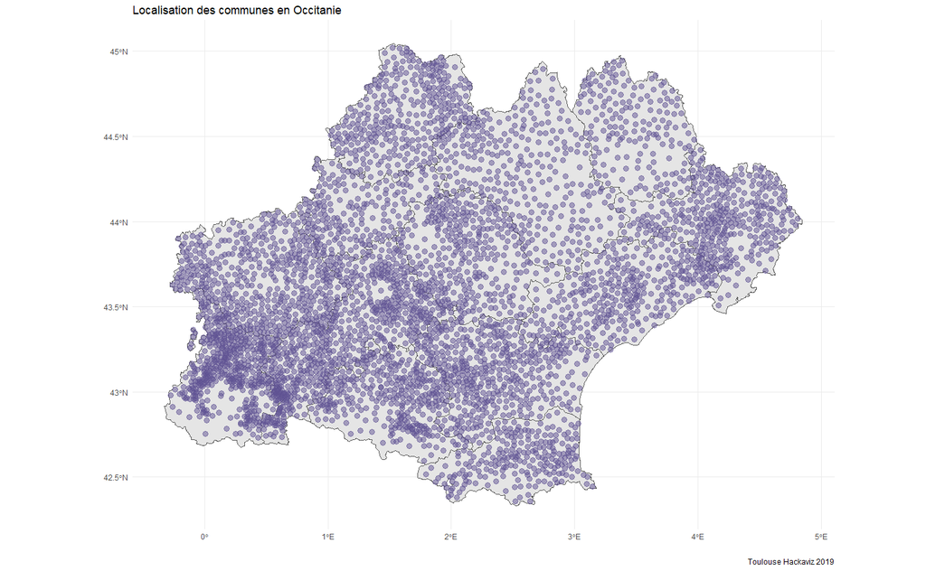

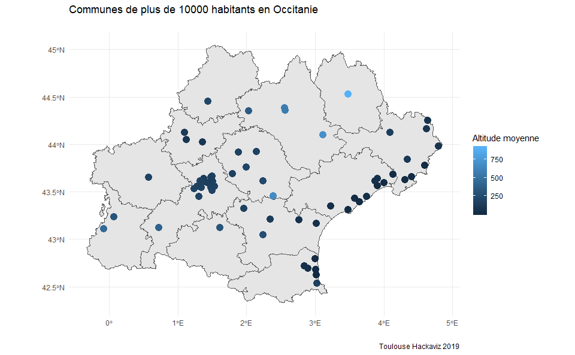

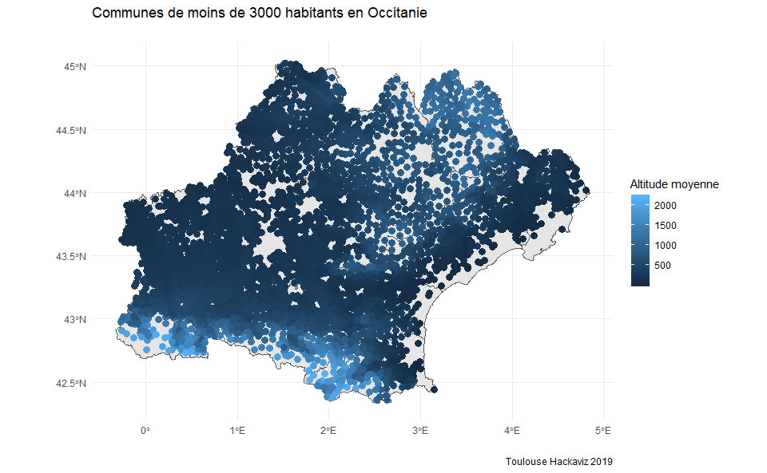

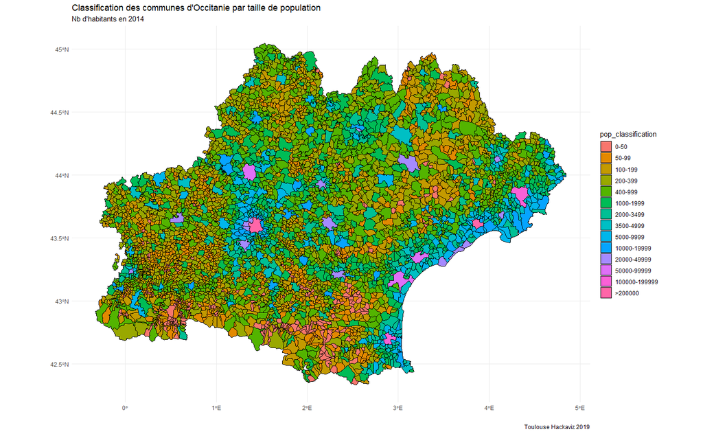

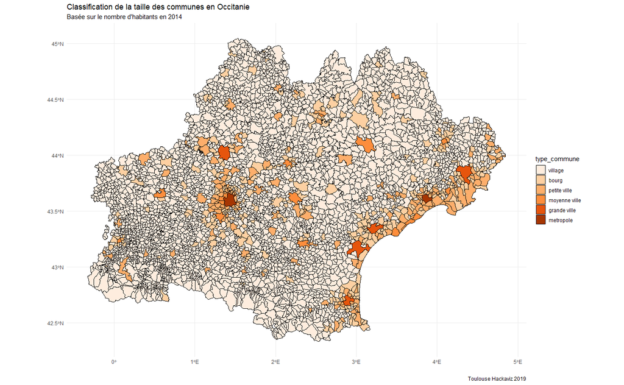

# Superficie communes

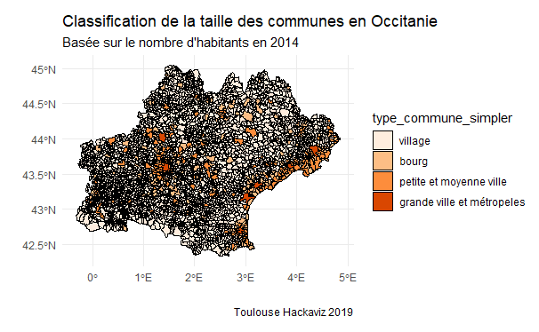

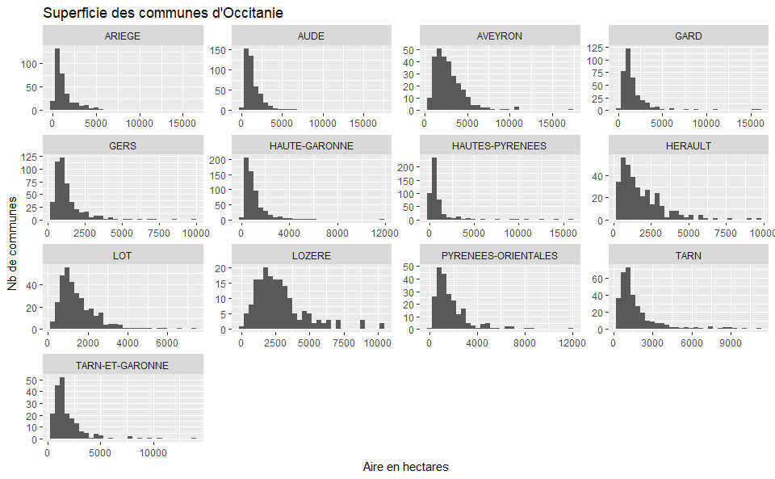

# Habitants

| departement_nom | moy | var | sd |
| --- | --- | --- | --- |
| ARIEGE | 459.5602 | 1492644 | 1221.738 |
| AUDE | 838.2523 | 12393244 | 3520.404 |
| AVEYRON | 974.2797 | 5210919 | 2282.744 |
| GARD | 2085.0680 | 72699215 | 8526.383 |
| GERS | 412.6082 | 1527401 | 1235.880 |
| HAUTE-GARONNE | 2237.1273 | 377672610 | 19433.801 |
| HAUTES-PYRENEES | 485.0636 | 4540197 | 2130.774 |
| HERAULT | 3228.5656 | 249226168 | 15786.899 |
| LOT | 532.6626 | 1690676 | 1300.260 |
| LOZERE | 433.8636 | 1070144 | 1034.478 |

[output cut: 3 more lines]

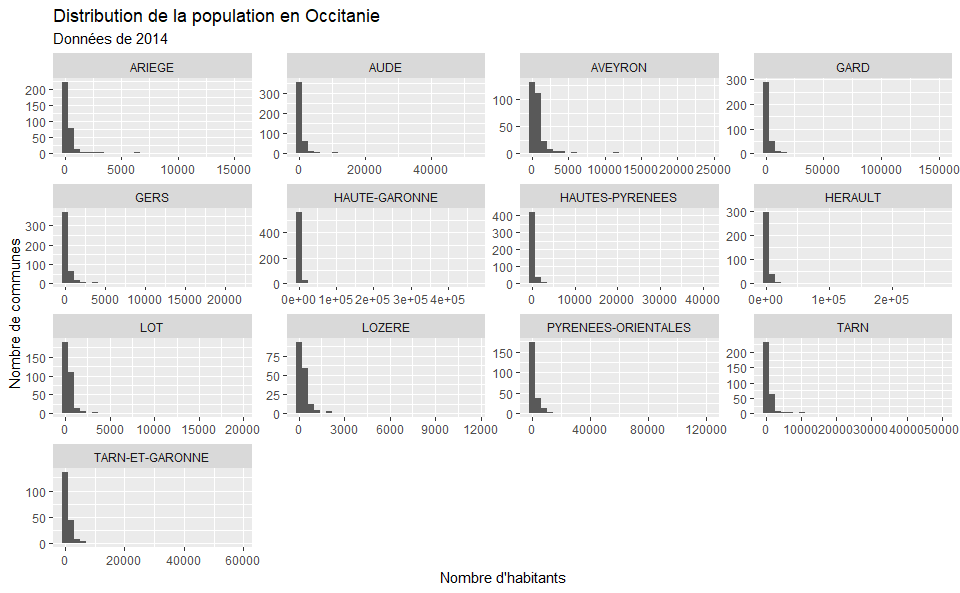

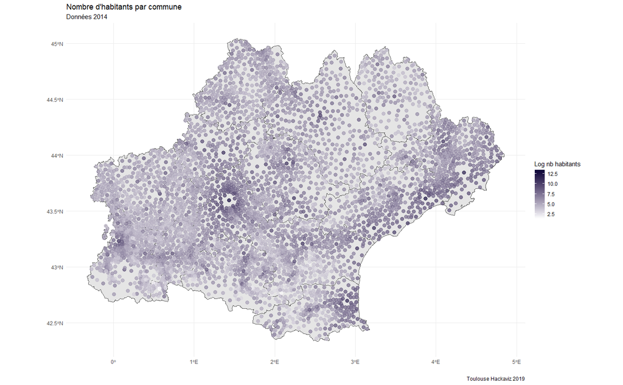

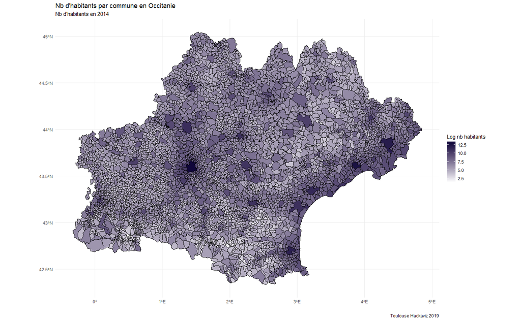

## Proportion d’habitants actifs

## Weird cases

Il y a quatres communes avec plus d’habitants actifs que d’habitants en 2014. La grosse différence est pour CAUNNETTE sur Lauquet (6 -> 23, ça fait une sacrée différence…).

| commune | habitants_2014 | personnes_actives_2014 |
| --- | --- | --- |
| CAUNETTE SUR LAUQUET | 6 | 23 |
| TREBONS DE LUCHON | 4 | 5 |
| OURDE | 34 | 35 |
| SAINT LANNE | 130 | 149 |

Et il y a des communes sans habitants actifs…

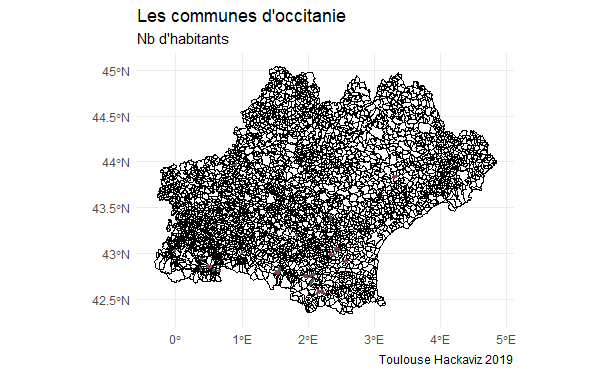

# Distribution

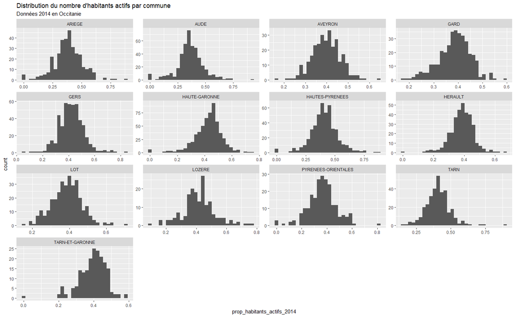

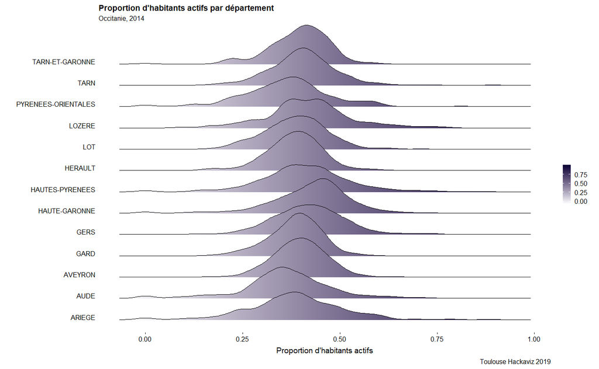

Comment est-ce que le nombre de personnes actives est correlé avec le nombre d’habitants ? La variance augmente avec le nombre d’habitants, mais les deux sont très bien correlées.

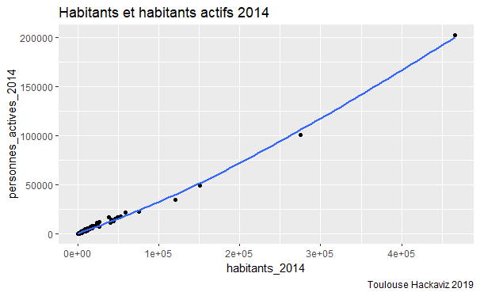

Pas la peine de se prendre trop la tête là dessus.

Une bonne carte des habitants actifs fera l’affaire :

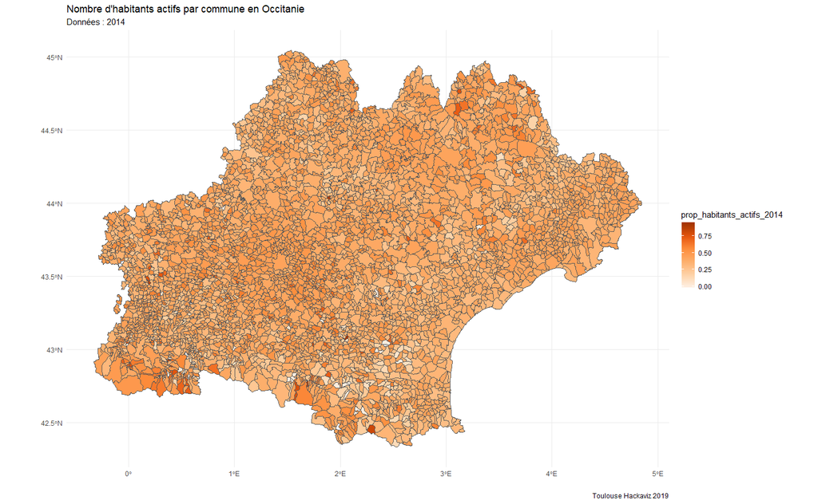

# Peuplement et taille

## Habitants et superficie

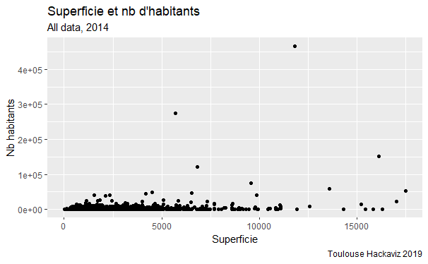

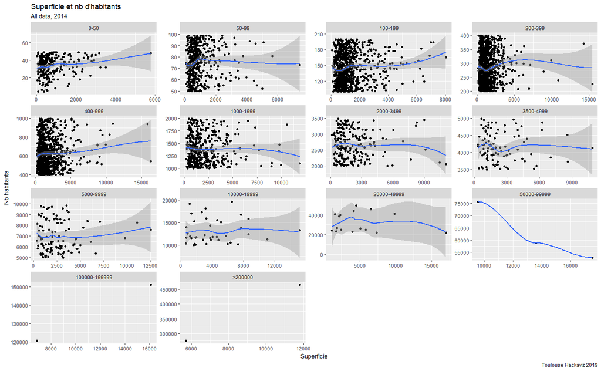

Si on enlève les communes super ultra peuplées

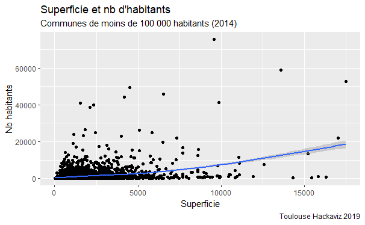

Le signal est pas ultra clair.

## Habitants actifs 2014 et superficie

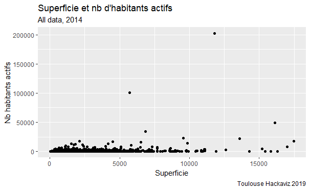

Si on enlève les communes super ultra peuplées

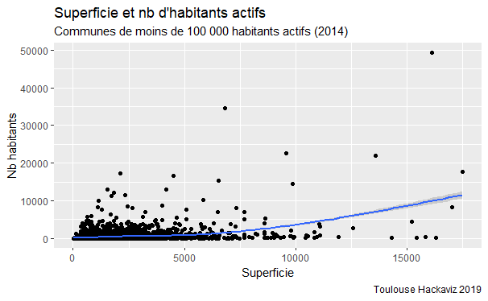

Signal pas ultra clair. Je pense que c’est parce que l’on a des petites communes peu peuplées, des petites communes très peuplées, et des grandes communes très peuplées (agglo) et des grandes communes peu peuplées (ex : dans les Pyrénées).

## Nb habitants per hectare

Pour résummer ce que je viens de regarder, je fais une variable habitants par hectare => densité de population.

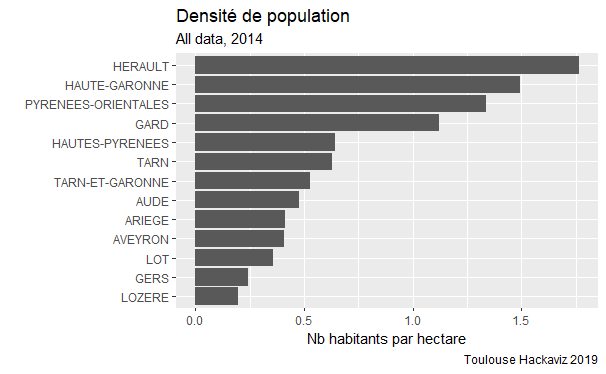

Toutes communes confondues, l’Herault a la plus forte densité de pop per commune, suivi de la Haute Garonne.

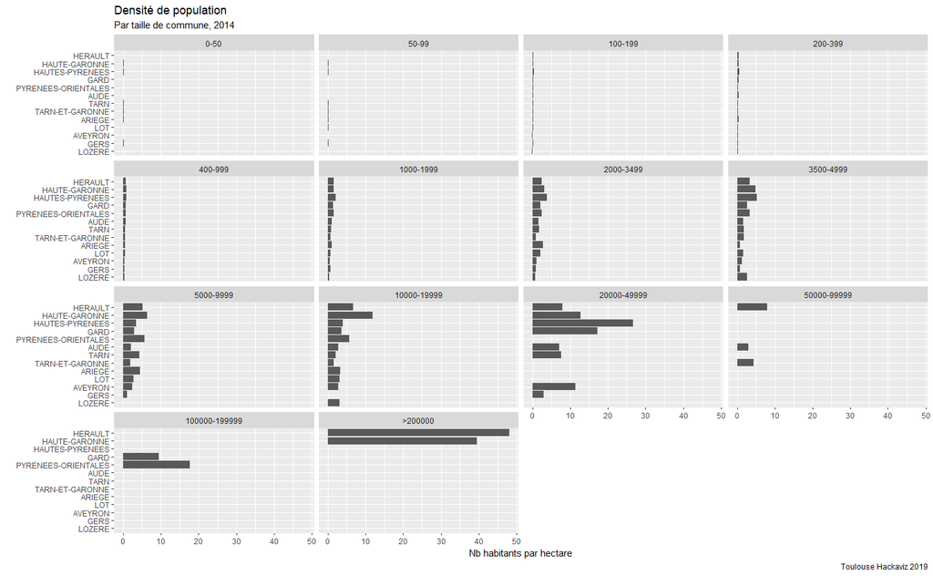

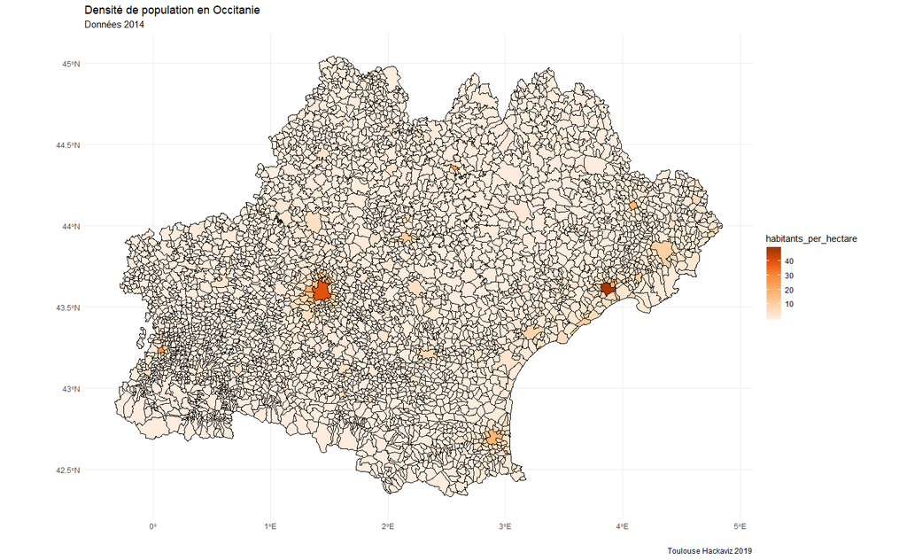

# Peuplement et altitude

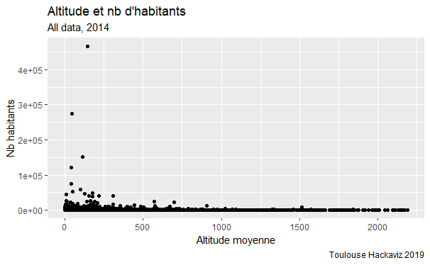

Bon, j’en ai marre, je crée des classes de population et d’altitude.

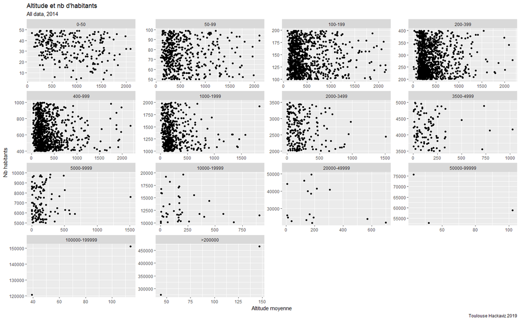

# Ménages 2014

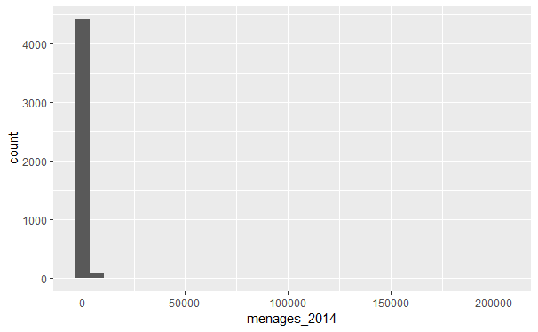

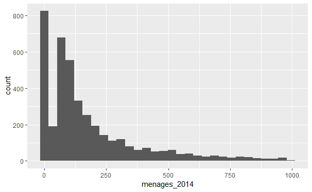

Communes avec zero ménages. Pourquoi ? Il y en a pas mal quand même… (824). Je propose de laisser tomber la mesure des ménages pour la suite, elle a l’air zarb.

| commune | menages_2014 | habitants_2014 | personnes_actives_2014 |
| --- | --- | --- | --- |
| AIGUES JUNTES | 0 | 58 | 36 |
| ALLIAT | 0 | 55 | 20 |
| ALLIERES | 0 | 71 | 35 |
| ANTRAS | 0 | 61 | 10 |
| APPY | 0 | 29 | 18 |
| ARABAUX | 0 | 60 | 21 |
| ARRIEN EN BETHMALE | 0 | 108 | 32 |
| ARROUT | 0 | 80 | 20 |
| ARTIGUES | 0 | 52 | 10 |
| AUCAZEIN | 0 | 64 | 28 |

[output cut: 814 more lines]